# MVA3

Sai Madhuri

2024-02-25

#Using auto-mpg data set from kaggle(https://www.kaggle.com/datasets/uciml/autompg-dataset?resource=download) and it contains the following attributes

mpg - Mileage/Miles Per Galon cylinders - the power unit of the car where gasoline is turned into power displacement - engine displacement of the car horsepower - rate of the engine performance weight - the weight of a car acceleration - the acceleration of a car model year- model year of the car origin - the origin of the car car - the name of the car

#Here mpg is the dependent variable and horsepower,weight,acceleration,cylinders, displacement etc are the independent variables.

```r
file_path <- "/Users/user/Downloads/auto-mpg.csv"
data <- read.csv(file_path)
autompg <- read.csv("/Users/user/Downloads/auto-mpg.csv")
str(autompg)
```

```
## 'data.frame':    398 obs. of  9 variables:
##  $ mpg         : num  18 15 18 16 17 15 14 14 14 15 ...
##  $ cylinders   : int  8 8 8 8 8 8 8 8 8 8 ...
##  $ displacement: num  307 350 318 304 302 429 454 440 455 390 ...
##  $ horsepower  : chr  "130" "165" "150" "150" ...
##  $ weight      : int  3504 3693 3436 3433 3449 4341 4354 4312 4425 3850 ...
##  $ acceleration: num  12 11.5 11 12 10.5 10 9 8.5 10 8.5 ...
##  $ model.year  : int  70 70 70 70 70 70 70 70 70 70 ...
##  $ origin      : int  1 1 1 1 1 1 1 1 1 1 ...
##  $ car.name    : chr  "chevrolet chevelle malibu" "buick skylark 320" "plymouth satellite" "amc rebel sst" ...
```

#considering mpg(miles per gallon) variable for univariate analysis

```r
mpg <- autompg$mpg
```

#calculating mean and variance of the mpg variable

```r
mpg_mean <- mean(mpg)
mpg_mean
```

```
## [1] 23.51457
```

```r
mpg_variance <- var(mpg)
mpg_variance
```

```
## [1] 61.08961
```

#Visualization of the mpg distribution

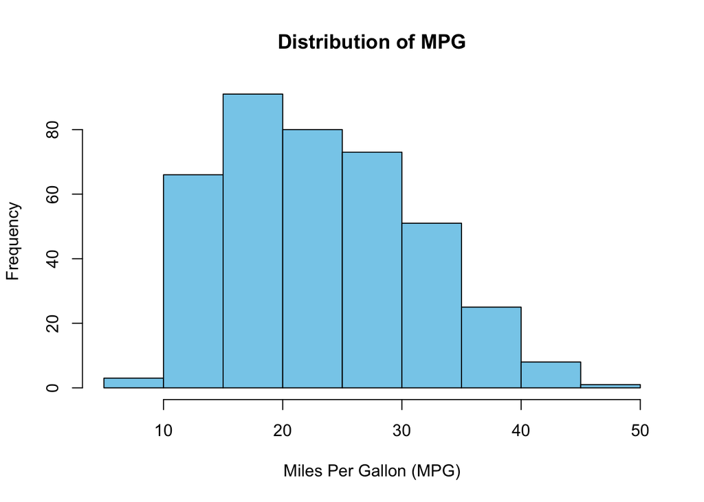

```r
hist(mpg, main = "Distribution of MPG", xlab = "Miles Per Gallon (MPG)", col = "skyblue", border = "black")
```

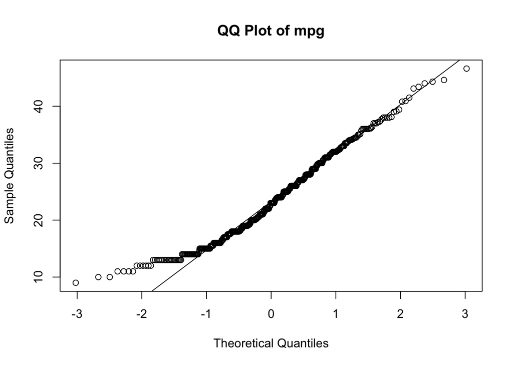

```r
#Q-Q plot of mpg variable.
qqnorm(autompg$mpg, main = "QQ Plot of mpg")
qqline(autompg$mpg)
```

#By calculating mean of the mpg variable, we got an insight of the average fuel efficiency of the vehicles in the data set.

#Variance values quantifies the spread of mpg values around the mean. Higher variance in this case indicates greater variability in fuel efficiency among the vehicles.

#Histogram visualization of MPG variable provides a graphical representation of the distribution of fuel efficiency in the dataset.It helps us to identify any potential outliers.

#Hence with univariate mean and variance analysis we can access the typical fuel efficiency of vehicles in the dataset.

#####Multivariate mean and variance analysis

```r
y <- autompg[, c(1,3,5)]
```

#Calculating mean and covariance

```r
auto_colmean <- colMeans(y)
auto_covariance <- cov(y)
auto_d <- apply(y, MARGIN = 1, function(y)t(y - auto_colmean) %*% solve(auto_covariance) %*% (y - auto_colmean))
#mean
auto_colmean
```

```
##          mpg displacement       weight
##     23.51457    193.42588   2970.42462
```

```r
#covariance

auto_covariance
```

```
##                      mpg displacement     weight
## mpg             61.08961    -655.4023  -5505.212
## displacement  -655.40232   10872.1992  82368.423
## weight       -5505.21175   82368.4232 717140.991
```

```r
#Mahalanobis distances for each observation to the vector auto_d.
auto_d
```

[output not shown]

[output cut: 52 more lines]

#The above analysis explains that there is a high negative covariance between mpg and weight which denotes there is a inverse relationship between them. As the weight of the vehicle increases mpg tends to decrease.A the same time mpg and displacement are also negatively related which means as the engine size(displacement) increases mpg tends to decrease.

#Here multivariate mean and variance analysis helped to understand the relationship between different variables.

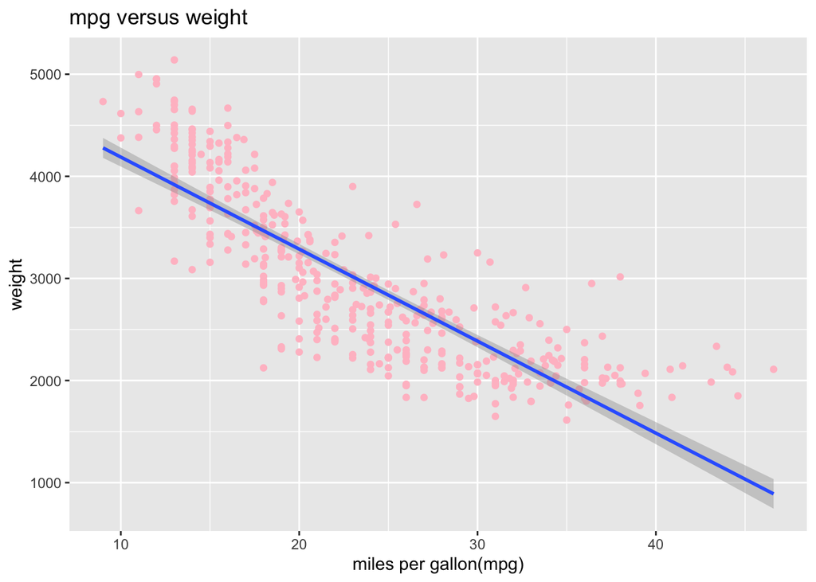

```r
#Visualization of the relationship between mpg and weight
library(ggplot2)
ggplot(autompg, aes(x = mpg, y = weight)) +
  geom_point(color = "pink") +
  labs(title = "mpg versus weight",
       x = "miles per gallon(mpg)",
       y = "weight") +  geom_smooth(method = "lm")
```

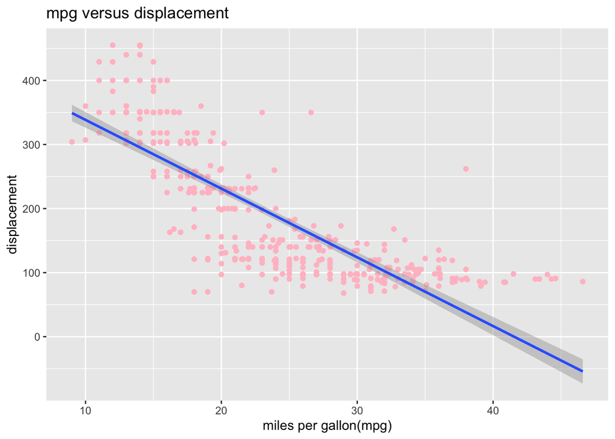

```r
#Visualization of the relationship between mpg and displacement
library(ggplot2)
ggplot(autompg, aes(x = mpg, y = displacement)) +
  geom_point(color = "pink") +
  labs(title = "mpg versus displacement",
       x = "miles per gallon(mpg)",
       y = "displacement") +  geom_smooth(method = "lm")
```

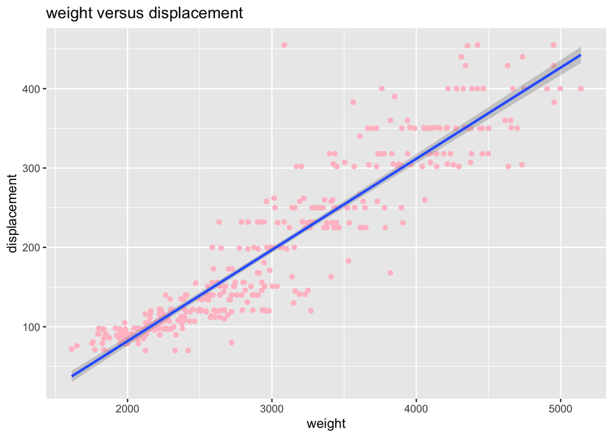

```r
#Visualization of the relationship between weight and displacement
library(ggplot2)
ggplot(autompg, aes(x = weight, y = displacement)) +
  geom_point(color = "pink") +
  labs(title = "weight versus displacement",
       x = "weight",
       y = "displacement") +  geom_smooth(method = "lm")
```